# Trabajo Práctico 1 - Tecnología Digital VI

Indira Imbellone, Nicolás Boudourian, Juan Ignacio Elosegui

Agosto 2025

# **Ejercicio 1**

## Descripción del conjunto de datos

El conjunto de datos a utilizar, “Adult Census Income”, se obtuvo del repositorio de datos de la Universidad de California en Irvine (UCI) y está disponible en la plataforma Kaggle. Este dataset contiene información de registros del censo de Estados Unidos de 1994 y tiene como objetivo predecir si el ingreso anual de un individuo es superior a 50.000 dólares o no.

## Principales variables incluidas

Variables numéricas: `age` (edad), `fnlwgt` (peso final), `education.num` (nivel educativo en formato numérico), `capital.gain` (ganancias de capital), `capital.loss` (pérdidas de capital) y `hours.per.week` (horas de trabajo semanales).

Variables categóricas: `workclass` (tipo de empleador), `education` (nivel de educación), `marital.status` (estado civil), `occupation` (ocupación), `relationship` (relación familiar), `race` (raza), `sex` (género) y `native.country` (país de origen).

El problema a resolver es de clasificación binaria, donde la variable objetivo, income, indica si el ingreso de un individuo es >50K o <=50K.

## Justificación para el uso de árboles de decisión

Este conjunto de datos es una elección adecuada para aplicar algoritmos de árboles de decisión, ya que cumple con las características requeridas para el trabajo práctico. La variable objetivo, `income`, es de naturaleza binaria, lo cual se alinea perfectamente con un problema de clasificación. Además, el dataset combina una variedad de atributos numéricos y categóricos. Los árboles de decisión son particularmente efectivos para manejar este tipo de datos mixtos sin la necesidad de una preprocesamiento complejo, como la codificación de variables categóricas o la escalada de variables numéricas, lo que simplifica el análisis.

# **Ejercicio 2**

## Cargamos las librerías necesarias

```r
library(rpart)
library(rpart.plot)
```

### Leemos el dataset directamente desde una URL

```r
url <- 'http://archive.ics.uci.edu/ml/machine-learning-databases/adult/adult.data'

adult_df <- read.csv(url,
                     header = FALSE,
                     col.names = c("age", "workclass", "fnlwgt", "education", "education.num", "marital.status", "occupation", "relationship", "race", "sex", "capital.gain", "capital.loss", "hours.per.week", "native.country", "income"),
                     na.strings = "?")
```

### Eliminamos las filas con valores faltantes

```r
adult_df <- na.omit(adult_df)
```

### Convertimos la variable `income` en un factor, que es esencial para la clasificación.

```r
adult_df$income <- as.factor(adult_df$income)
```

## Crear el árbol de decisión

`income ~ .` le dice al modelo que prediga la variable `income` usando todas las otras variables del conjunto de datos. `method = "class"` es para problemas de clasificación.

```r
arbol_basico <- rpart(income ~ ., data = adult_df, method = "class")
```

## Visualizar el árbol de decisión

`rpart.plot` crea un gráfico claro y fácil de leer del árbol. `extra = 101` agrega porcentajes en los nodos, lo que ayuda a interpretar los resultados.

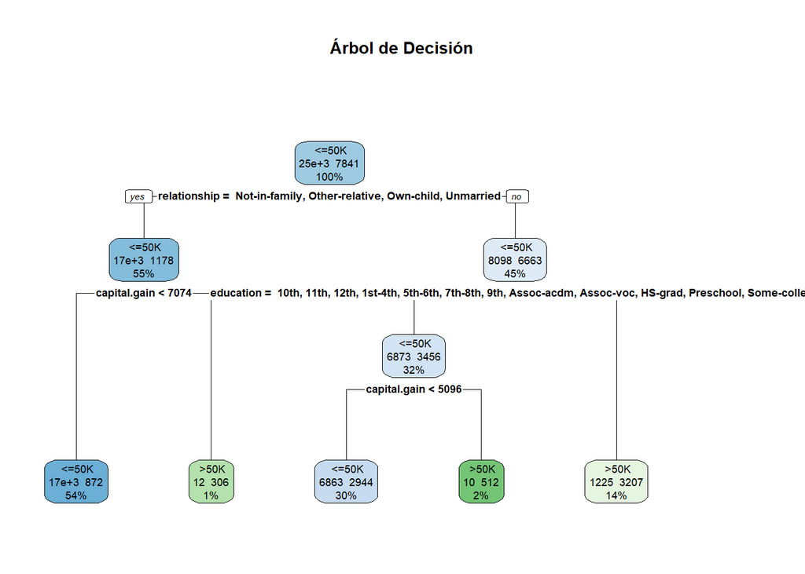

```r
rpart.plot(arbol_basico, extra = 101, main = "Árbol de Decisión")
```